# GEO880 - CMA: Exercise 3

Gregory Biland

5/3/2022

```r
caro <- read_delim(file.path(dataFolder, "caro60.csv"))
caro <- as.data.frame(caro)
```

## Task 1

The sampling interval for this data set is 1 minute. Use a temporal window v of 6 minutes, i.e. a window size of 6 positions (n±3).

```r
caro <- caro %>%
  mutate(
    nMinus3 = sqrt((lag(E,3)-E)^2+(lag(N,3)-N)^2),   # distance to pos -3 minutes
    nMinus2 = sqrt((lag(E,2)-E)^2+(lag(N,2)-N)^2),   # distance to pos -2 minutes
    nMinus1 = sqrt((lag(E,1)-E)^2+(lag(N,1)-N)^2),   # distance to pos -1 minutes
    nPlus1  = sqrt((E-lead(E,1))^2+(N-lead(N,1))^2), # distance to pos +1 mintues
    nPlus2  = sqrt((E-lead(E,2))^2+(N-lead(N,2))^2),  # distance to pos +2 minutes
    nPlus3  = sqrt((E-lead(E,3))^2+(N-lead(N,3))^2)  # distance to pos +3 minutes
  )

caro <- caro %>%
  rowwise() %>%
  mutate(
    stepMean = mean(c(nMinus3,nMinus2, nMinus1,nPlus1,nPlus2,nPlus3))
  ) %>%
  ungroup()
```

## Task 2

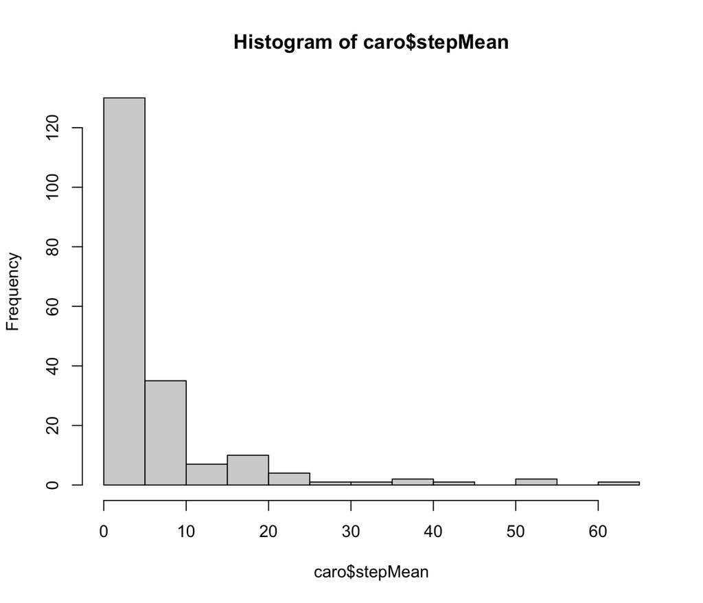

```r
hist(caro$stepMean)
```

```r
summary(caro$stepMean)
```

```
##    Min. 1st Qu.  Median    Mean 3rd Qu.    Max.    NA's
##   1.431   2.729   3.962   6.951   6.164  62.368       6
```

```r
caro <- caro %>%
  ungroup() %>%
  mutate(static = stepMean < 10) #When the stepmean is smaller than 10, all the movement is considered as static, otherwise the movement is non-static

caro_filter <- caro %>%
  filter(!static)
```

## Task 3

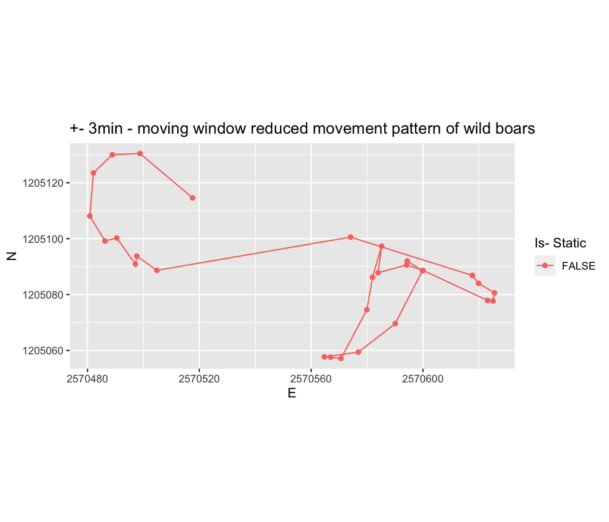

```r
caro_filter%>%
  ggplot(aes(E, N, col = static))  +
  geom_path() +
  geom_point() +
  coord_equal() +
  theme(legend.position = "right")+
  ggtitle("+- 3min - moving window reduced movement pattern of wild boars")+
  labs(colour="Is- Static")
```

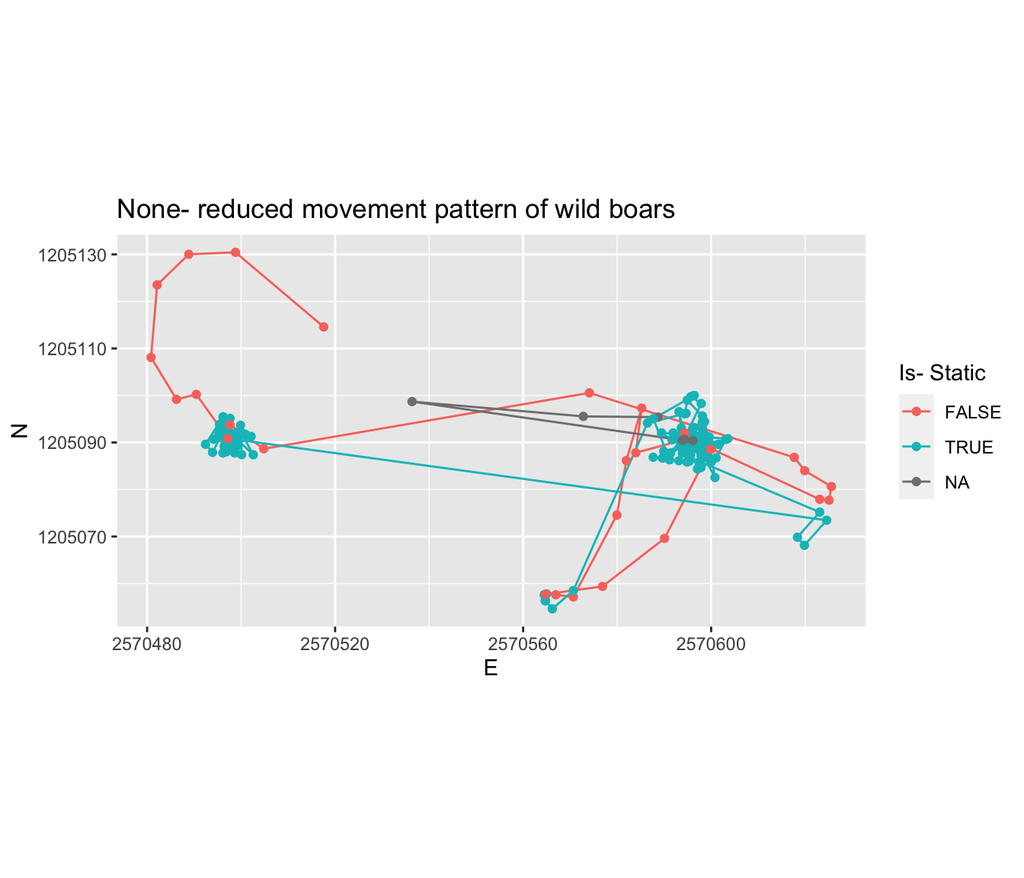

```r
caro%>%
  ggplot(aes(E, N, col = static))  +
  geom_path() +
  geom_point() +
  coord_equal() +
  theme(legend.position = "right")+
  ggtitle("None- reduced movement pattern of wild boars")+
  labs(colour="Is- Static")
```

## Task 4

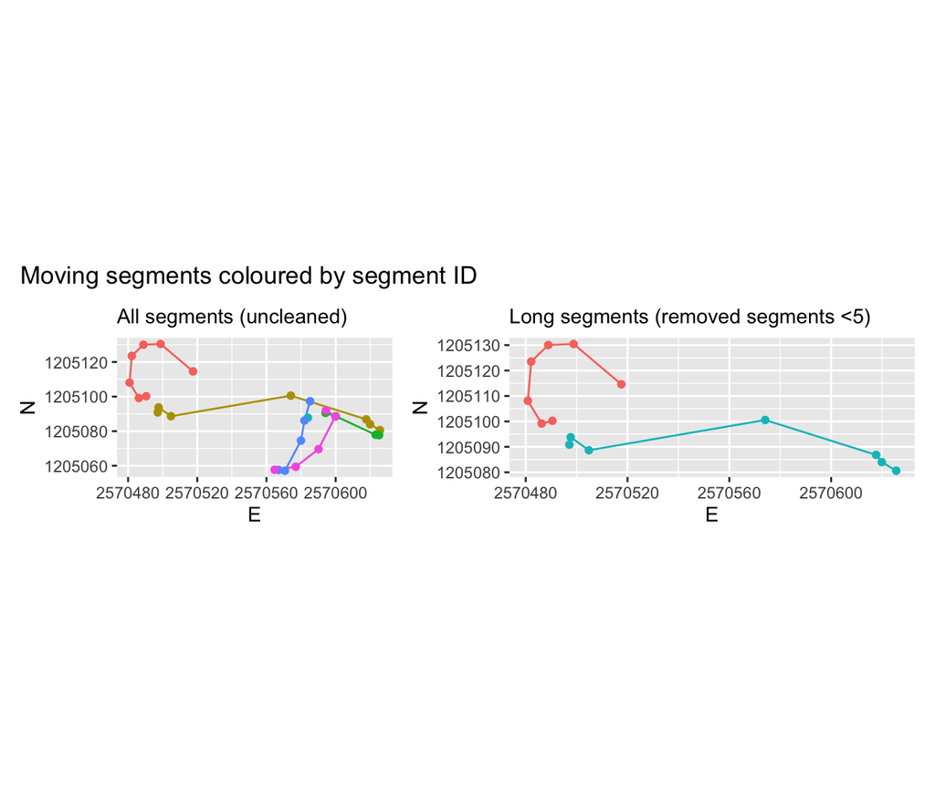

```r
rle_id <- function(vec){
  x <- rle(vec)$lengths
  as.factor(rep(seq_along(x), times=x))
}

caro <- caro %>%
  mutate(segment_id = rle_id(static))

caro_seg_filter <- caro %>%
  filter(!static)

caro_seg5 <- caro_seg_filter %>%
  group_by(segment_id) %>%
  filter(length(segment_id) > 5)

p1 <- caro_seg_filter %>%
  ggplot(aes(E, N, col = segment_id))  +
  geom_path() +
  geom_point() +
  coord_equal() +
  theme(legend.position = "none")+
  ggtitle("All segments (uncleaned)")+
  theme(plot.title = element_text(size=11))

p2 <- caro_seg5 %>%
  ggplot(aes(E, N, col = segment_id))  +
  geom_path() +
  geom_point() +
  coord_equal() +
  theme(legend.position = "none")+
  ggtitle("Long segments (removed segments <5)")+
  theme(plot.title = element_text(size=11))

p1 + p2 + patchwork::plot_annotation(title = "Moving segments coloured by segment ID")
```

## Task 5

```r
ped <- read_delim(file.path(dataFolder, "pedestrian.csv")) %>% data.frame()
```

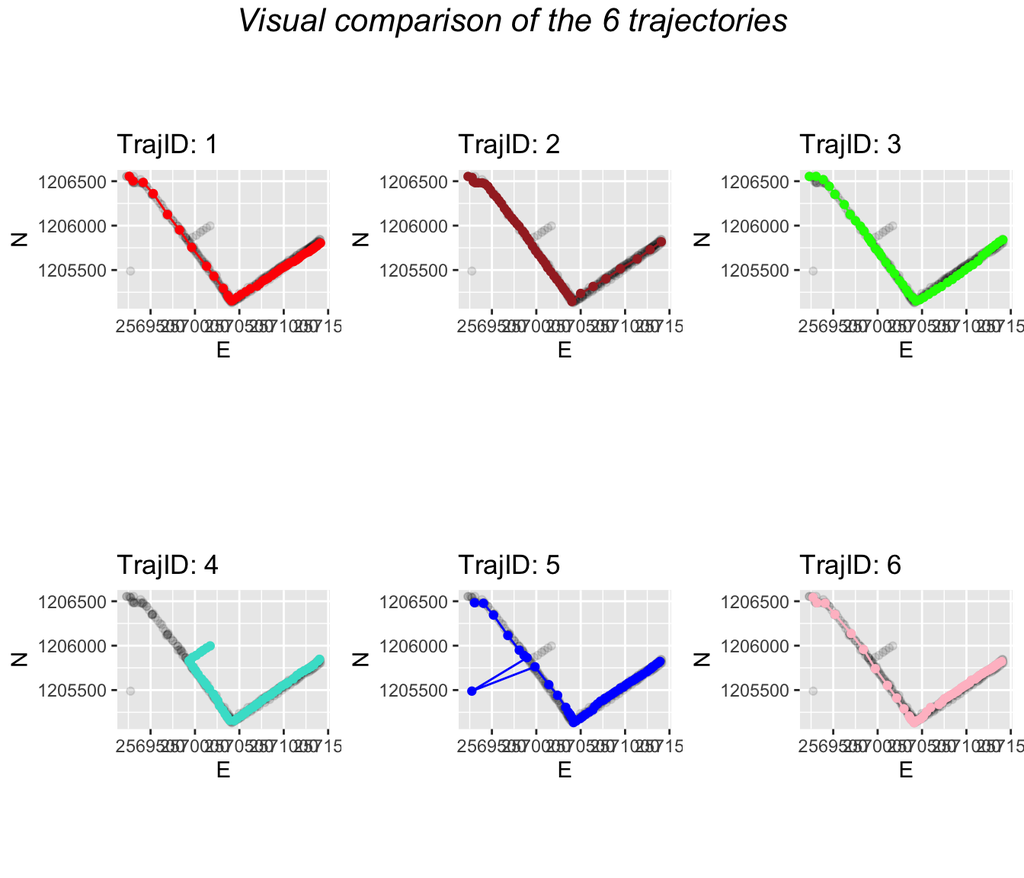

```r
t1 <- ggplot()  +
  geom_point(ped, mapping = aes(E,N), alpha = .1 )+
  geom_point(subset(ped, TrajID %in% "1"), mapping = aes(E,N), color = "red")+
  geom_path(subset(ped, TrajID %in% "1"), mapping = aes(E, N), color = "red") +
  coord_equal() +
  theme(legend.position = "none")+
  ggtitle("TrajID: 1")

t2 <- ggplot()  +
  geom_point(ped, mapping = aes(E,N), alpha = .1 )+
  geom_point(subset(ped, TrajID %in% "2"), mapping = aes(E, N), color = "brown")+
  geom_path(subset(ped, TrajID %in% "2"), mapping = aes(E, N), color = "brown") +
  coord_equal() +
  theme(legend.position = "none")+
  ggtitle("TrajID: 2")

t3 <- ggplot()  +
  geom_point(ped, mapping = aes(E,N), alpha = .1 )+
  geom_point(subset(ped, TrajID %in% "3"), mapping = aes(E, N), color = "green")+
  geom_path(subset(ped, TrajID %in% "3"), mapping = aes(E, N), color = "green") +
  coord_equal() +
  theme(legend.position = "none")+
  ggtitle("TrajID: 3")

t4 <- ggplot()  +
  geom_point(ped, mapping = aes(E,N), alpha = .1 )+
  geom_point(subset(ped, TrajID %in% "4"), mapping = aes(E, N), color = "turquoise")+
  geom_path(subset(ped, TrajID %in% "4"), mapping = aes(E, N), color = "turquoise") +
  coord_equal() +
  theme(legend.position = "none")+
  ggtitle("TrajID: 4")

t5 <- ggplot()  +
  geom_point(ped, mapping = aes(E,N), alpha = .1 )+
  geom_point(subset(ped, TrajID %in% "5"), mapping = aes(E, N), color = "blue")+
  geom_path(subset(ped, TrajID %in% "5"), mapping = aes(E, N), color = "blue") +
  coord_equal() +
  theme(legend.position = "none")+
  ggtitle("TrajID: 5")

t6 <- ggplot()  +
  geom_point(ped, mapping = aes(E,N), alpha = .1 )+
  geom_point(subset(ped, TrajID %in% "6"), mapping = aes(E, N), color = "pink")+
  geom_path(subset(ped, TrajID %in% "6"), mapping = aes(E, N), color = "pink") +
  coord_equal() +
  theme(legend.position = "none")+
  ggtitle("TrajID: 6")

grid.arrange(t1,t2,t3,t4,t5,t6, nrow = 2, top = textGrob("Visual comparison of the 6 trajectories",gp=gpar(fontsize=16,font=3)))
```

## Task 6

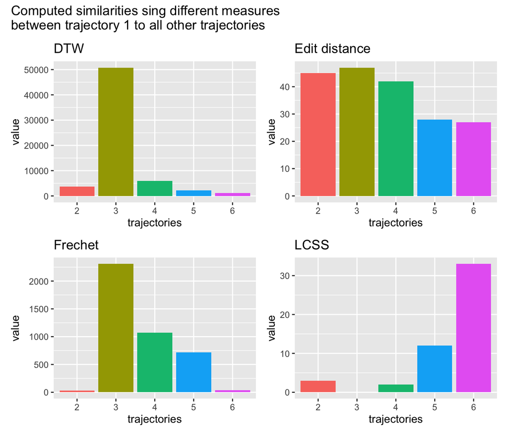

```r
#Creating subsets and transform them to unique matrices.
tr1 <- ped %>% filter(TrajID == 1)
tr1$TrajID <- NULL
tr1$DatetimeUTC <- NULL
tr1 <- as.matrix(tr1)

tr2 <- ped %>% filter(TrajID == 2)
tr2$TrajID <- NULL
tr2$DatetimeUTC <- NULL
tr2 <- as.matrix(tr2)

tr3 <- ped %>% filter(TrajID == 3)
tr3$TrajID <- NULL
tr3$DatetimeUTC <- NULL
tr3 <- as.matrix(tr3)

tr4 <- ped %>% filter(TrajID == 4)
tr4$TrajID <- NULL
tr4$DatetimeUTC <- NULL
tr4 <- as.matrix(tr4)

tr5 <- ped %>% filter(TrajID == 5)
tr5$TrajID <- NULL
tr5$DatetimeUTC <- NULL
tr5 <- as.matrix(tr5)

tr6 <- ped %>% filter(TrajID == 6)
tr6$TrajID <- NULL
tr6$DatetimeUTC <- NULL
tr6 <- as.matrix(tr6)

# Methods
frechet_1_2 <- Frechet(tr1,tr2)
frechet_1_3 <- Frechet(tr1,tr3)
frechet_1_4 <- Frechet(tr1,tr4)
frechet_1_5 <- Frechet(tr1,tr5)
frechet_1_6 <- Frechet(tr1,tr6)

lcss_1_2 <- LCSS(tr1,tr2, pointSpacing = 1)
lcss_1_3 <- LCSS(tr1,tr3, pointSpacing = 1)
lcss_1_4 <- LCSS(tr1,tr4, pointSpacing = 1)
lcss_1_5 <- LCSS(tr1,tr5, pointSpacing = 1)
lcss_1_6 <- LCSS(tr1,tr6, pointSpacing = 1)

dtw_1_2 <- DTW(tr1,tr2)
dtw_1_3 <- DTW(tr1,tr3)
dtw_1_4 <- DTW(tr1,tr4)
dtw_1_5 <- DTW(tr1,tr5)
dtw_1_6 <- DTW(tr1,tr6)

edit_1_2 <- EditDist(tr1,tr2)
edit_1_3 <- EditDist(tr1,tr3)
edit_1_4 <- EditDist(tr1,tr4)
edit_1_5 <- EditDist(tr1,tr5)
edit_1_6 <- EditDist(tr1,tr6)

# Creating df for all 4 different methods
edit_df <- data.frame(trajectories = c("2", "3", "4", "5", "6"), value = c(edit_1_2, edit_1_3, edit_1_4, edit_1_5, edit_1_6))
frechet_df <- data.frame(trajectories = c("2", "3", "4", "5", "6"), value = c(frechet_1_2, frechet_1_3, frechet_1_4, frechet_1_5, frechet_1_6))
dtw_df <- data.frame(trajectories = c("2", "3", "4", "5", "6"), value = c(dtw_1_2, dtw_1_3, dtw_1_4, dtw_1_5, dtw_1_6))
lcss_df <- data.frame(trajectories = c("2", "3", "4", "5", "6"), value = c(lcss_1_2, lcss_1_3, lcss_1_4, lcss_1_5, lcss_1_6))

dtw_plot <- ggplot()+
  geom_bar(data = dtw_df, aes(trajectories,value, fill = trajectories), stat = "identity")+
  theme(legend.position = "none")+
  ggtitle("DTW")

edit_plot <- ggplot()+
  geom_bar(data = edit_df, aes(trajectories,value, fill = trajectories), stat = "identity")+
  theme(legend.position = "none")+
  ggtitle("Edit distance")

frechet_plot <- ggplot()+
  geom_bar(data = frechet_df, aes(trajectories,value, fill = trajectories), stat = "identity")+
  theme(legend.position = "none")+
  ggtitle("Frechet")

lcss_plot <- ggplot()+
  geom_bar(data = lcss_df, aes(trajectories,value, fill = trajectories), stat = "identity")+
  theme(legend.position = "none")+
  ggtitle("LCSS")

dtw_plot + edit_plot + frechet_plot+lcss_plot+ patchwork::plot_annotation(title = "Computed similarities sing different measures
between trajectory 1 to all other trajectories")
```

Can you see connections between the properties of the trajectories and the similarity values computed by the different measures?

- It is relatively difficult to see the connections. For example, for trajectory 2 and 3, the values for the dtw measurement are completely different although they are both very similar compared to trajectory. Similarly, trajectory 6 has the highest similarity to 1 but the lowest dtw measurement value. The same is true for the other methods. Paths that are very similar do not have the same values across the band for the same measurement method even though from aug the paths actually look exactly the same. Only the LCSS value for the comparison of paths 1 and 6 clearly show the similarities with a PointSpacing of 1 and show that these paths are very similar even with a small threshold.